# Introduction

## What is R and why use it?

R is a free software environment with its own programming language.

It is especailly suited for statistical analysis and graphical outputs.

R's popularity as a data science tool as well as it being open source has made its applications vast.

R can work with a large variety of data formats and is (with a few add-ons) compatible with data from other software solutions (Excel, SPSS, SAS, STATA).

## A Short Demo

(demo on R Studio server)

## Content of the R introduction

- The R language
- The RStudio environment
- Constructing variables and objects
- Working with tables (dataframes)
- Using the help command
- Libraries/packages
- Simple visualizations (`ggplot2` package)

The introduction will combine presenting R and R code in Jupyter Notebook while demonstrating in RStudio. You are encouraged to work and write in RStudio during the workshop.

*Please write along as we go through the different examples.*

## The RStudio environment

During the workshop (and the other R workshops in CALDISS), we will be working with RStudio.

RStudio is an IDE for R (Integrated Development Environment) - Makes for a nicer workspace

https://www.rstudio.com/products/rstudio/download/

# The R language

R has it's own programming language. R works by you writing lines of code in that language (writing commands) and R interpreting that code (running commands).

R (and RStudio) has a limited user interface meaning almost all functionality (statistics, plots, simulations etc.) must be executed using code in the R language.

## R as a calculator

So what does it mean that R interprets our code? It means that you tell R to do something by writing a command and R will do that (if R can understand you).

R, for example, understands mathematical expressions:

```r
2 + 5
```

7

```r
0.37 * 256
```

94.72

# The R Language: Objects and Functions

R works by storing value in "objects". These objects can then be used in various commands like calculating a statistical model, saving a file, creating a graph and so on. To simplify a bit: An object is some kind of stored value and a function is something that can manipulate a stored value (which then creates a new object).

Most of R can be boiled down to these 3 basic steps:

1. Assign values to an object
2. Make sure R interprets the object correctly (its class)
3. Perfom some operation or manipulation on the object using a function

Translated to data analysis, the steps would (in general terms) look as follows:

1. Load our dataset: `data <- read.csv("my_datafile.csv")`
2. Check the that the variables are the correct class: `class(data$age)`
3. Perform some kind of analysis: `mean(data$age)`

The gap between these steps of course vary greatly.

## Objects

A lot of writing in R is about defining objects: A name to use to call up stored data.

Objects can be a lot of things:

- a word
- a number
- a series of numbers
- a dataset
- a URL
- a formula
- a result
- a filepath
- and so on...

When an object is defined, it is available in the current working space (or environment).

This makes it possible to store and work with a variety of informaiton simultaneously.

### Defining objects

Objects are defined using the `<-` operator:

```r
a <- 2 + 5
```

```r
a
```

7

```r
b <- 'jedi'
```

```r
b
```

'jedi'

Using `' '` or `" "` denotes that the code should be read as text.

### Naming objects

Objects can be named almost anything but a good rule of thumb is to use names that are indicative of what the object contains.

#### Restrictions for naming objects

- Most special characters not allowed: `/`, `?`, `*`, `+` and so on (most characters mean something to R and will be read as an expression)
- Already existing names in R (will overwrite the function/object in the environment)

#### Good naming conventions

- Using '`_`': `my_object`, `room_number`

or:

- Capitalize each word except the first: `myObject`, `roomNumber`

# EXERCISE 1: DEFINING OBJECTS

1. Define the following objects:
   - `my_num1`: `42` (without quotation marks)
   - `my_num2`: `"42"` (with quotation marks)
   - `my_calc`: `42 * 42`
   - `my_name`: `"kenobi"`
2. Multiply each object by 2

# EXERCISE 1: DEFINING OBJECTS

*What happens?*

```r
my_num1 * 2
```

84

```r
my_num2 * 2
```

```
Error in my_num2 * 2: non-numeric argument to binary operator
Traceback:
```

```r
my_calc * 2
```

3528

```r
my_name * 2
```

```
Error in my_name * 2: non-numeric argument to binary operator
Traceback:
```

# Different types of objects (classes)

Why did we get errors in the previous exercise?

Because R distinguishes between different types of objects!

An objects is stored as a *class*. The class denotes what type of object it is and affects what operations are possible.

## Numeric and character classes

As you work with R, you will encounter a lot of different classes. For now we will be focusing on two of the more common ones:

- Numeric classes
- Character classes

Numbers are automatically stored as a numeric class (or one of the variants: double, integer etc.).

When using `''` or `""` around the information to be stored in the object, R will interpret that as text; meaning it will be stored as a character class.

*Numbers enclosed in `''` or `""` are therefore stored as a character class, as R interprets it as text!*

R has to be told that something is text as R would otherwise interpret it as an object.

```r
my_name2 <- vader
```

```
Error in eval(expr, envir, enclos): objekt 'vader' blev ikke fundet
Traceback:
```

## Coercing classes

The class of an object can be examined with `class(object)`.

Objects can be coerced with specific functions:

- Coerce to character class:`as.character(object)`
- Coerce to numeric class: `as.numeric(object)`

R will always try to "guess" the class. If R guesses wrong, you can tell R what class it should be (if possible).

# R scripts: For reproducability!

Script files are text files containing code that R can interpret.

It is your "analysis recipe" showing what you have done as well as allowing you to re-run commands easily.

Always make a habit of writing your commands into a script, when you have the command figured out.

- `#` can be used for comments (skipped when run)
- `Ctrl` + `Enter`: Runs the current line or selection
- `Ctrl` + `Alt` + `R`: Runs the whole script

# EXERCISE 2: CLASSES

1. Create the object `my_product` containing the product of your 2 my_num objects: `my_num1 * my_num2`
2. Check the error message. What's wrong?
3. Change the class of `my_num2` to `numeric` (use `as.numeric()` and overwrite `my_num2`)
4. Try creating the object `my_product` again
5. Check if `my_product` is equal to `my_calc` using `==`. Assign it to the object `my_test`
6. Check the class of `my_test`. What class is it?

```r
my_num2 <- as.numeric(my_num2)
my_product <- my_num1 * my_num2
```

```r
my_test <- my_product == my_calc
my_test
```

TRUE

```r
class(my_test)
```

'logical'

# The logical class

Logicals are *boolean* objects meaning they will either have the value `TRUE` or `FALSE`.

When using the following operators (among others), R will interpret it as a logical class:

- `>`
- `>=`
- `<`
- `<=`
- `==`
- `!=`

Logicals can be used in functions, loops and if-statements to ensure that a certain condition is met before something is run.

# R Objects: Vectors

So far we have looked at R objects containing single values: a number, a word or a boolean.

R has different ways of storing a series of elements (values, objects, etc.). One of the more common is the *vector*.

A vector is a grouping of elements. They are created using the function `c`:

```r
my_vec <- c(1, 9, 7, 3)
my_vec
```

1. 1

2. 9

3. 7

4. 3

Elements can be added to the vector with the function `append` or by creating a vector containing the vector:

```r
my_vec2 <- append(my_vec, 22)
my_vec2
```

1. 1

2. 9

3. 7

4. 3

5. 22

```r
my_vec3 <- c(my_vec, 22)
my_vec3
```

1. 1

2. 9

3. 7

4. 3

5. 22

# R Objects: Vectors

Note that a vector is not a class. The class it takes depends on the elements in the vector. This means that all elements in a vector have to be the same class (or will be coerced to the same class).

Also note that when grouping existing objects in a vector, the vector does not contain the objects but the values of those objects.

```r
class(my_vec)
```

'numeric'

## Operations on a vector

Operations on vectors are applied on all elements in the vector:

```r
my_vec
```

1. 1

2. 9

3. 7

4. 3

```r
2 * my_vec
```

1. 2

2. 18

3. 14

4. 6

```r
my_vec > 5
```

1. FALSE

2. TRUE

3. TRUE

4. FALSE

## Subsetting a vector

Each element in the vector is assigned an index running from 1 to the number of elements. We can use the index to refer to specific elements with `[]`:

```r
2 * my_vec[2]
```

18

Subsetting can also be used to overwrite values:

```r
my_vec
```

1. 1

2. 9

3. 7

4. 3

```r
my_vec[2] <- 11
my_vec
```

1. 1

2. 11

3. 7

4. 3

## Useful operations and functions on vectors

Below are some examples of different commands to interact with vectors.

| Code | Description |
| --- | --- |
| `my_vec[-3]` | Everything but the 3rd element |
| `my_vec[c(1,4)]` | The 1st and 4th element |
| `my_vec[c(2:4)]` | The elements from index 2 to 4 |
| `length(my_vec)` | The number of elements |
| `sort(my_vec)` | Sorts the elements in ascending order |
| `sum(my_vec)` | The sum of the vector elements (numeric) |
| `mean(my_vec)` | The mean of the vector elements (numeric) |
| `min(my_vec)` | The vector element with the lowest value (numeric) |
| `max(my_vec)` | The vector element with the highest value (numeric) |

# EXERCISE 3: VECTORS

1. Create the vector `my_numvec` containing the objects: `my_num1`, `my_num2`, `my_calc`, `my_product` (`my_num2` should be numeric)
2. Check the class with `class()` - What class is it?
3. Calculate the sum of the numbers with `sum()`

### BONUS EXERCISE

1. Can you add `my_name` to the same vector?
2. If so, what class would the vector be?

```r
# EXERCISE 3
my_numvec <- c(my_num1, my_num2, my_calc, my_product)
```

```r
class(my_numvec)
```

'numeric'

```r
sum(my_numvec)
```

3612

```r
# EXERCISE 3 - BONNUS
my_numvec <- c(my_numvec, my_name)
```

```r
class(my_numvec)
```

'character'

# R Objects: Data Frames

A "data frame" is the R-equivalent of a spreadsheet (a table of rows and columns). It is one of the most useful storage structures for data analysis in R.

Typically rows consist of individual observations and the columns of the different variables (tidy data).

R comes with some built-in datasets like `mtcars` (see all the avaiable datasets with `data()`)

The built-in datasets (like `mtcars`) can be loaded with the command `data(mtcars)`.

*Load the `mtcars` dataset now*

## Exploring Data Frames

To get an idea of what the data contains, we can use `head(mtcars)`:

```r
head(mtcars) #Shows the 6 first rows of each observation
```

|  | mpg | cyl | disp | hp | drat | wt | qsec | vs | am | gear | carb |
| --- | --- | --- | --- | --- | --- | --- | --- | --- | --- | --- | --- |
| Mazda RX4 | 21.0 | 6 | 160 | 110 | 3.90 | 2.620 | 16.46 | 0 | 1 | 4 | 4 |
| Mazda RX4 Wag | 21.0 | 6 | 160 | 110 | 3.90 | 2.875 | 17.02 | 0 | 1 | 4 | 4 |
| Datsun 710 | 22.8 | 4 | 108 | 93 | 3.85 | 2.320 | 18.61 | 1 | 1 | 4 | 1 |
| Hornet 4 Drive | 21.4 | 6 | 258 | 110 | 3.08 | 3.215 | 19.44 | 1 | 0 | 3 | 1 |
| Hornet Sportabout | 18.7 | 8 | 360 | 175 | 3.15 | 3.440 | 17.02 | 0 | 0 | 3 | 2 |
| Valiant | 18.1 | 6 | 225 | 105 | 2.76 | 3.460 | 20.22 | 1 | 0 | 3 | 1 |

We can check the names of the rows and columns (the variable names) using `rownames` and `colnames`:

```r
rownames(mtcars)
```

1. 'Mazda RX4'

2. 'Mazda RX4 Wag'

3. 'Datsun 710'

4. 'Hornet 4 Drive'

5. 'Hornet Sportabout'

6. 'Valiant'

7. 'Duster 360'

8. 'Merc 240D'

9. 'Merc 230'

10. 'Merc 280'

11. 'Merc 280C'

12. 'Merc 450SE'

13. 'Merc 450SL'

14. 'Merc 450SLC'

15. 'Cadillac Fleetwood'

16. 'Lincoln Continental'

17. 'Chrysler Imperial'

18. 'Fiat 128'

19. 'Honda Civic'

20. 'Toyota Corolla'

21. 'Toyota Corona'

22. 'Dodge Challenger'

23. 'AMC Javelin'

24. 'Camaro Z28'

25. 'Pontiac Firebird'

26. 'Fiat X1-9'

27. 'Porsche 914-2'

28. 'Lotus Europa'

29. 'Ford Pantera L'

30. 'Ferrari Dino'

31. 'Maserati Bora'

32. 'Volvo 142E'

```r
colnames(mtcars)
```

1. 'mpg'

2. 'cyl'

3. 'disp'

4. 'hp'

5. 'drat'

6. 'wt'

7. 'qsec'

8. 'vs'

9. 'am'

10. 'gear'

11. 'carb'

## Subsetting Data Frames

Specific columns/variables can be called by their name using `$`:

```r
head(mtcars$mpg) #6 first rows of the variable "Miles per galon"
```

1. 21

2. 21

3. 22.8

4. 21.4

5. 18.7

6. 18.1

Data frames can also be subset via index: `[]` - either by index or column names:

| Code | Description |
| --- | --- |
| `mtcars[2, 5]` | Row 2, column 5 |
| `mtcars[2, "drat"]` | Row 2, column "drat" (column 5) |
| `mtcars[10, ]` | The entire 10th row |
| `mtcars[, 10]` | The entire 10th column |

## Operations on a data frame

Each column in a data frame works like a vector. Functions can therefore be used on data frame columns like they can be used on vectors:

```r
mean(mtcars$mpg)
```

20.090625

```r
min(mtcars$mpg)
```

10.4

```r
2 * mtcars$mpg
```

1. 42

2. 42

3. 45.6

4. 42.8

5. 37.4

6. 36.2

7. 28.6

8. 48.8

9. 45.6

10. 38.4

11. 35.6

12. 32.8

13. 34.6

14. 30.4

15. 20.8

16. 20.8

17. 29.4

18. 64.8

19. 60.8

20. 67.8

21. 43

22. 31

23. 30.4

24. 26.6

25. 38.4

26. 54.6

27. 52

28. 60.8

29. 31.6

30. 39.4

31. 30

32. 42.8

## Creating variables

Variables can be added to a data frame using the operator `$` and calling a name not yet used in the data frame:

```r
mtcars$wtpergear <- mtcars$wt / mtcars$gear
```

If we want to remove a variable (for example one that does not make sense at all), we can assign it the value `NULL`:

```r
colnames(mtcars)
```

1. 'mpg'

2. 'cyl'

3. 'disp'

4. 'hp'

5. 'drat'

6. 'wt'

7. 'qsec'

8. 'vs'

9. 'am'

10. 'gear'

11. 'carb'

12. 'wtpergear'

```r
mtcars$wtpergear <- NULL
```

```r
colnames(mtcars)
```

1. 'mpg'

2. 'cyl'

3. 'disp'

4. 'hp'

5. 'drat'

6. 'wt'

7. 'qsec'

8. 'vs'

9. 'am'

10. 'gear'

11. 'carb'

# The R Help Files

All R functions and commands are thoroughly documented so you do not have to remember what every function does or even how it should be written.

Every function and command in R has its own help file. The help file describes how to use the various functions and commands.

The help file for a specific function is accessed using the operator `?` (also works for the built-in datasets):

```r
?sum
```

When in doubt, just look up the help file.

# EXERCISE 4: DATA FRAMES

Using the same operations as on vectors to solve the following.

1. Load the `mtcars` dataset: `data(mtcars)`
2. Determine how heavy the heaviest car is (the variable `wt`)
3. Having the car names stored as row names can give problems later. Create a new variable called `car` containing the name of the car (the row names) - remember how the `$` operator works!
4. The variable `wt` is "weight in 1000 lbs". Add the variable `wtkg` that contains the weight in 1000 kg

   1 lbs = 0.453592 kg

### BONUS EXERCISE

1. Look up the help file for the function `which.min` and `which.max`
2. Using the functions above, can you determine which car is the lightest and which car is heaviest?

# Saving files

Check your directory with `getwd`. Directory can be changed with `setwd`.

We can save a .csv-file (comma-separated values) with `write.table`:

```r
write.table(mtcars, file = "my_mtcars.csv", sep = ",", col.names = TRUE)
```

**Code breakdown:**

| Code | Description |
| --- | --- |
| `mtcars` | The object we want to save |
| `file = "my_mtcars.csv"` | The filename - .csv for comma-separated values |
| `sep = ","` | Setting the separator between values to be commas |

A .csv-file is a multi-platform format and can be loaded by most statistical software (Excel, STATA, etc.).

## Reading files

Make sure you are in the right working directory (`getwd`)

```r
my_mtcars <- read.table(file = "my_mtcars.csv", header = TRUE, sep = ",")
```

**Code breakdown:**

| Code | Description |  |
| --- | --- | --- |
| `file = "my_mtcars.csv"` | The filename - .csv for comma-separated values |  |
| `header = TRUE` | Telling R that our data has headers (column names) |  |
| `sep = ","` | Telling R what the separator between values is | * |

# R Libraries - Packages

R being open source means that a lot of developers are constantly adding new functions to R. These new functions are distributed as *R packages* that can be loaded into the R library.

All the commands you have been using so far have been part of the `base` package (ships with R).

Packages are installed using (name of package *with* quotes!):

`install.packages('packagename')`

The functions from the package is loaded into the environment using (name of package *without* quotes!):

`library(packagename)`

Information for installed packages can be found using (name of package *with* quotes!):

`library(help = 'packagename')`

# Visuazliation in R - `ggplot2`

`ggplot2` is a package for creating plots and visuazliation. Histograms, scatterplots, lineplots and so on.

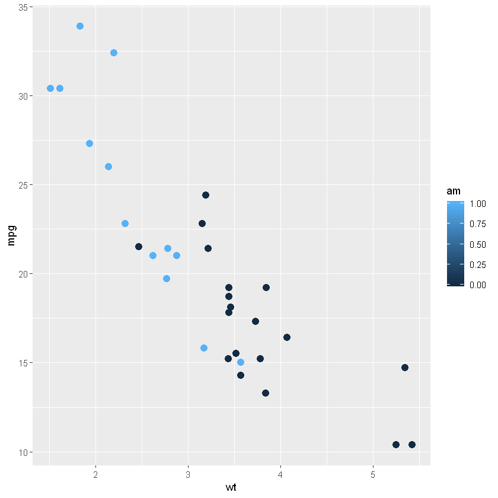

```r
ggplot(data = mtcars, aes(x = wt, y = mpg, colour = am)) +
    geom_point(size = 3)
```

**Code breakdown:**

| Code | Description |
| --- | --- |
| `data = mtcars` | What data to use |
| `aes()` | Sets the aesthetics - parameters for the plot |
| `x = wt` | Sets the x-variable - refers to `wt` in the dataset `mtcars` |
| `y = mpg` | Sets the y-variable - refers to `mpg` in the dataset `mtcars` |
| `colour = am` | Optional colouring of values based on 3rd variable |
| `+` | Indicates that the plot is not done |
| `geom_point()` | Creates a scatterplot based on the parameters |
| `size = 3` | Sets the size of the dots in the scatterplot |

# EXERCISE 6: `ggplot2`

1. Install the package `ggplot2` and load it.
2. Create a histogram of the variable `mpg` in `mtcars` with `ggplot` and `geom_histogram()` (one variable, so only x needs to be specified. No colour)
3. Create a scatterplot of `wtkg` and `qsec` using `geom_point`.

*What does the data tell us?*

# Summation of day 1

R objects are created using the operator `<-`. R objects can be pretty much anything.

Objects are assigned a `class`. The class can be checked with `class(object)`. Classes can be coerced with commands like `as.numeric()` or `as.character()`

Vectors are groupings of values. They are created with `c()`. Vectors can be subset using `[]`.

Data frames are R's version of a spreadsheet (rows and columns). A column/variable can be selected using `$`. A column/variable can (in most cases) be treated like a vector.

Data frames can be subset using `[ , ]`. Rows are specified before the comma, and columns after the comma.

Other functions can be loaded into R via packages.

The package `ggplot2` can be used for visualizations.